# TPM calculation

Laura Toribio-Celestino

10/16/2021

### Loading required packages

```r
library(dplyr)
library(ggplot2)
library(CustomSelection)
library(reshape2)
```

## Importing the TPM tables and assessing normalization approaches

Following files include TPM values of chromosomal and pOXA-48 genes (other plasmid’s genes were filtered out after TPM calculation in each strain’s R project), for each replicate, and the median TPM values between replicates.

```r
files <- list.files(pattern = "*_chr_pOXA48.tsv")
for (i in 1:length(files)) assign(files[i], read.table(files[i], header = TRUE))
```

Calculating the median TPM values of chromosomal expression across replicates and strains and coefficient of variance:

```r
medianschr <- c()
medianschr <- c(medianschr, median(TPM_EC10_chr_pOXA48.tsv[TPM_EC10_chr_pOXA48.tsv$Chr == "Chromosome", 2]))
medianschr <- c(medianschr, median(TPM_EC10_chr_pOXA48.tsv[TPM_EC10_chr_pOXA48.tsv$Chr == "Chromosome", 3]))
medianschr <- c(medianschr, median(TPM_EC10_chr_pOXA48.tsv[TPM_EC10_chr_pOXA48.tsv$Chr == "Chromosome", 4]))
medianschr <- c(medianschr, median(TPM_C325_chr_pOXA48.tsv[TPM_C325_chr_pOXA48.tsv$Chr == "Chromosome", 2]))
medianschr <- c(medianschr, median(TPM_C325_chr_pOXA48.tsv[TPM_C325_chr_pOXA48.tsv$Chr == "Chromosome", 3]))
medianschr <- c(medianschr, median(TPM_C325_chr_pOXA48.tsv[TPM_C325_chr_pOXA48.tsv$Chr == "Chromosome", 4]))
medianschr <- c(medianschr, median(TPM_CF13_chr_pOXA48.tsv[TPM_CF13_chr_pOXA48.tsv$Chr == "Chromosome", 2]))
medianschr <- c(medianschr, median(TPM_CF13_chr_pOXA48.tsv[TPM_CF13_chr_pOXA48.tsv$Chr == "Chromosome", 3]))
medianschr <- c(medianschr, median(TPM_CF13_chr_pOXA48.tsv[TPM_CF13_chr_pOXA48.tsv$Chr == "Chromosome", 4]))
medianschr <- c(medianschr, median(TPM_H53_chr_pOXA48.tsv[TPM_H53_chr_pOXA48.tsv$Chr == "Chromosome", 2]))
medianschr <- c(medianschr, median(TPM_H53_chr_pOXA48.tsv[TPM_H53_chr_pOXA48.tsv$Chr == "Chromosome", 3]))
medianschr <- c(medianschr, median(TPM_H53_chr_pOXA48.tsv[TPM_H53_chr_pOXA48.tsv$Chr == "Chromosome", 4]))
medianschr <- c(medianschr, median(TPM_J57_chr_pOXA48.tsv[TPM_J57_chr_pOXA48.tsv$Chr == "Chromosome", 2]))
medianschr <- c(medianschr, median(TPM_J57_chr_pOXA48.tsv[TPM_J57_chr_pOXA48.tsv$Chr == "Chromosome", 3]))
medianschr <- c(medianschr, median(TPM_J57_chr_pOXA48.tsv[TPM_J57_chr_pOXA48.tsv$Chr == "Chromosome", 4]))
medianschr <- c(medianschr, median(TPM_KPN04_chr_pOXA48.tsv[TPM_KPN04_chr_pOXA48.tsv$Chr == "Chromosome", 2]))
medianschr <- c(medianschr, median(TPM_KPN04_chr_pOXA48.tsv[TPM_KPN04_chr_pOXA48.tsv$Chr == "Chromosome", 3]))
medianschr <- c(medianschr, median(TPM_KPN04_chr_pOXA48.tsv[TPM_KPN04_chr_pOXA48.tsv$Chr == "Chromosome", 4]))
medianschr <- c(medianschr, median(TPM_KPN07_chr_pOXA48.tsv[TPM_KPN07_chr_pOXA48.tsv$Chr == "Chromosome", 2]))
medianschr <- c(medianschr, median(TPM_KPN07_chr_pOXA48.tsv[TPM_KPN07_chr_pOXA48.tsv$Chr == "Chromosome", 3]))
medianschr <- c(medianschr, median(TPM_KPN07_chr_pOXA48.tsv[TPM_KPN07_chr_pOXA48.tsv$Chr == "Chromosome", 4]))
medianschr <- c(medianschr, median(TPM_K147_chr_pOXA48.tsv[TPM_K147_chr_pOXA48.tsv$Chr == "Chromosome", 2]))
medianschr <- c(medianschr, median(TPM_K147_chr_pOXA48.tsv[TPM_K147_chr_pOXA48.tsv$Chr == "Chromosome", 3]))
medianschr <- c(medianschr, median(TPM_K147_chr_pOXA48.tsv[TPM_K147_chr_pOXA48.tsv$Chr == "Chromosome", 4]))
medianschr <- c(medianschr, median(TPM_K147_chr_pOXA48.tsv[TPM_K147_chr_pOXA48.tsv$Chr == "Chromosome", 5]))
medianschr <- c(medianschr, median(TPM_KPN10_chr_pOXA48.tsv[TPM_KPN10_chr_pOXA48.tsv$Chr == "Chromosome", 2]))
medianschr <- c(medianschr, median(TPM_KPN10_chr_pOXA48.tsv[TPM_KPN10_chr_pOXA48.tsv$Chr == "Chromosome", 3]))
medianschr <- c(medianschr, median(TPM_KPN15_chr_pOXA48.tsv[TPM_KPN15_chr_pOXA48.tsv$Chr == "Chromosome", 2]))
medianschr <- c(medianschr, median(TPM_KPN15_chr_pOXA48.tsv[TPM_KPN15_chr_pOXA48.tsv$Chr == "Chromosome", 3]))
medianschr <- c(medianschr, median(TPM_KPN15_chr_pOXA48.tsv[TPM_KPN15_chr_pOXA48.tsv$Chr == "Chromosome", 4]))
medianschr <- c(medianschr, median(TPM_KPN18_chr_pOXA48.tsv[TPM_KPN18_chr_pOXA48.tsv$Chr == "Chromosome", 2]))
medianschr <- c(medianschr, median(TPM_KPN18_chr_pOXA48.tsv[TPM_KPN18_chr_pOXA48.tsv$Chr == "Chromosome", 3]))
medianschr <- c(medianschr, median(TPM_KPN18_chr_pOXA48.tsv[TPM_KPN18_chr_pOXA48.tsv$Chr == "Chromosome", 4]))
medianschr <- c(medianschr, median(TPM_MG1655_chr_pOXA48.tsv[TPM_MG1655_chr_pOXA48.tsv$Chr == "Chromosome", 2]))
medianschr <- c(medianschr, median(TPM_MG1655_chr_pOXA48.tsv[TPM_MG1655_chr_pOXA48.tsv$Chr == "Chromosome", 3]))
# Coefficient of variance
sd(medianschr)/mean(medianschr)
```

```
## [1] 0.220601
```

Calculating the coefficient of variance of the rpoD, dnaE and recA housekeeping genes across samples:

```r
rpoD_tpm <- c()
rpoD_tpm <- c(rpoD_tpm, TPM_EC10_chr_pOXA48.tsv[TPM_EC10_chr_pOXA48.tsv$GeneID == "cds-pgaptmp_000668", 2])
rpoD_tpm <- c(rpoD_tpm, TPM_EC10_chr_pOXA48.tsv[TPM_EC10_chr_pOXA48.tsv$GeneID == "cds-pgaptmp_000668", 3])
rpoD_tpm <- c(rpoD_tpm, TPM_EC10_chr_pOXA48.tsv[TPM_EC10_chr_pOXA48.tsv$GeneID == "cds-pgaptmp_000668", 4])
rpoD_tpm <- c(rpoD_tpm, TPM_C325_chr_pOXA48.tsv[TPM_C325_chr_pOXA48.tsv$GeneID == "cds-pgaptmp_004157", 2])
rpoD_tpm <- c(rpoD_tpm, TPM_C325_chr_pOXA48.tsv[TPM_C325_chr_pOXA48.tsv$GeneID == "cds-pgaptmp_004157", 3])
rpoD_tpm <- c(rpoD_tpm, TPM_C325_chr_pOXA48.tsv[TPM_C325_chr_pOXA48.tsv$GeneID == "cds-pgaptmp_004157", 4])
rpoD_tpm <- c(rpoD_tpm, TPM_CF13_chr_pOXA48.tsv[TPM_CF13_chr_pOXA48.tsv$GeneID == "cds-pgaptmp_004138", 2])
rpoD_tpm <- c(rpoD_tpm, TPM_CF13_chr_pOXA48.tsv[TPM_CF13_chr_pOXA48.tsv$GeneID == "cds-pgaptmp_004138", 3])
rpoD_tpm <- c(rpoD_tpm, TPM_CF13_chr_pOXA48.tsv[TPM_CF13_chr_pOXA48.tsv$GeneID == "cds-pgaptmp_004138", 4])
rpoD_tpm <- c(rpoD_tpm, TPM_H53_chr_pOXA48.tsv[TPM_H53_chr_pOXA48.tsv$GeneID == "cds-pgaptmp_000651", 2])
rpoD_tpm <- c(rpoD_tpm, TPM_H53_chr_pOXA48.tsv[TPM_H53_chr_pOXA48.tsv$GeneID == "cds-pgaptmp_000651", 3])
rpoD_tpm <- c(rpoD_tpm, TPM_H53_chr_pOXA48.tsv[TPM_H53_chr_pOXA48.tsv$GeneID == "cds-pgaptmp_000651", 4])
rpoD_tpm <- c(rpoD_tpm, TPM_J57_chr_pOXA48.tsv[TPM_J57_chr_pOXA48.tsv$GeneID == "cds-pgaptmp_000656", 2])
rpoD_tpm <- c(rpoD_tpm, TPM_J57_chr_pOXA48.tsv[TPM_J57_chr_pOXA48.tsv$GeneID == "cds-pgaptmp_000656", 3])
rpoD_tpm <- c(rpoD_tpm, TPM_J57_chr_pOXA48.tsv[TPM_J57_chr_pOXA48.tsv$GeneID == "cds-pgaptmp_000656", 4])
rpoD_tpm <- c(rpoD_tpm, TPM_KPN04_chr_pOXA48.tsv[TPM_KPN04_chr_pOXA48.tsv$GeneID == "cds-pgaptmp_000647", 2])
rpoD_tpm <- c(rpoD_tpm, TPM_KPN04_chr_pOXA48.tsv[TPM_KPN04_chr_pOXA48.tsv$GeneID == "cds-pgaptmp_000647", 3])
rpoD_tpm <- c(rpoD_tpm, TPM_KPN04_chr_pOXA48.tsv[TPM_KPN04_chr_pOXA48.tsv$GeneID == "cds-pgaptmp_000647", 4])
rpoD_tpm <- c(rpoD_tpm, TPM_KPN07_chr_pOXA48.tsv[TPM_KPN07_chr_pOXA48.tsv$GeneID == "cds-pgaptmp_000647", 2])
rpoD_tpm <- c(rpoD_tpm, TPM_KPN07_chr_pOXA48.tsv[TPM_KPN07_chr_pOXA48.tsv$GeneID == "cds-pgaptmp_000647", 3])
rpoD_tpm <- c(rpoD_tpm, TPM_KPN07_chr_pOXA48.tsv[TPM_KPN07_chr_pOXA48.tsv$GeneID == "cds-pgaptmp_000647", 4])
rpoD_tpm <- c(rpoD_tpm, TPM_K147_chr_pOXA48.tsv[TPM_K147_chr_pOXA48.tsv$GeneID == "cds-pgaptmp_000664", 2])
rpoD_tpm <- c(rpoD_tpm, TPM_K147_chr_pOXA48.tsv[TPM_K147_chr_pOXA48.tsv$GeneID == "cds-pgaptmp_000664", 3])
rpoD_tpm <- c(rpoD_tpm, TPM_K147_chr_pOXA48.tsv[TPM_K147_chr_pOXA48.tsv$GeneID == "cds-pgaptmp_000664", 4])
rpoD_tpm <- c(rpoD_tpm, TPM_K147_chr_pOXA48.tsv[TPM_K147_chr_pOXA48.tsv$GeneID == "cds-pgaptmp_000664", 5])
rpoD_tpm <- c(rpoD_tpm, TPM_KPN10_chr_pOXA48.tsv[TPM_KPN10_chr_pOXA48.tsv$GeneID == "cds-pgaptmp_000647", 2])
rpoD_tpm <- c(rpoD_tpm, TPM_KPN10_chr_pOXA48.tsv[TPM_KPN10_chr_pOXA48.tsv$GeneID == "cds-pgaptmp_000647", 3])
rpoD_tpm <- c(rpoD_tpm, TPM_KPN15_chr_pOXA48.tsv[TPM_KPN15_chr_pOXA48.tsv$GeneID == "cds-pgaptmp_000667", 2])
rpoD_tpm <- c(rpoD_tpm, TPM_KPN15_chr_pOXA48.tsv[TPM_KPN15_chr_pOXA48.tsv$GeneID == "cds-pgaptmp_000667", 3])
rpoD_tpm <- c(rpoD_tpm, TPM_KPN15_chr_pOXA48.tsv[TPM_KPN15_chr_pOXA48.tsv$GeneID == "cds-pgaptmp_000667", 4])
rpoD_tpm <- c(rpoD_tpm, TPM_KPN18_chr_pOXA48.tsv[TPM_KPN18_chr_pOXA48.tsv$GeneID == "cds-pgaptmp_000667", 2])
rpoD_tpm <- c(rpoD_tpm, TPM_KPN18_chr_pOXA48.tsv[TPM_KPN18_chr_pOXA48.tsv$GeneID == "cds-pgaptmp_000667", 3])
rpoD_tpm <- c(rpoD_tpm, TPM_KPN18_chr_pOXA48.tsv[TPM_KPN18_chr_pOXA48.tsv$GeneID == "cds-pgaptmp_000667", 4])
rpoD_tpm <- c(rpoD_tpm, TPM_MG1655_chr_pOXA48.tsv[TPM_MG1655_chr_pOXA48.tsv$GeneID == "cds-pgaptmp_000649", 2])
rpoD_tpm <- c(rpoD_tpm, TPM_MG1655_chr_pOXA48.tsv[TPM_MG1655_chr_pOXA48.tsv$GeneID == "cds-pgaptmp_000649", 3])
dnaE_tpm <- c()
dnaE_tpm <- c(dnaE_tpm, TPM_EC10_chr_pOXA48.tsv[TPM_EC10_chr_pOXA48.tsv$GeneID == "cds-pgaptmp_003922", 2])
dnaE_tpm <- c(dnaE_tpm, TPM_EC10_chr_pOXA48.tsv[TPM_EC10_chr_pOXA48.tsv$GeneID == "cds-pgaptmp_003922", 3])
dnaE_tpm <- c(dnaE_tpm, TPM_EC10_chr_pOXA48.tsv[TPM_EC10_chr_pOXA48.tsv$GeneID == "cds-pgaptmp_003922", 4])
dnaE_tpm <- c(dnaE_tpm, TPM_C325_chr_pOXA48.tsv[TPM_C325_chr_pOXA48.tsv$GeneID == "cds-pgaptmp_002432", 2])
dnaE_tpm <- c(dnaE_tpm, TPM_C325_chr_pOXA48.tsv[TPM_C325_chr_pOXA48.tsv$GeneID == "cds-pgaptmp_002432", 3])
dnaE_tpm <- c(dnaE_tpm, TPM_C325_chr_pOXA48.tsv[TPM_C325_chr_pOXA48.tsv$GeneID == "cds-pgaptmp_002432", 4])
dnaE_tpm <- c(dnaE_tpm, TPM_CF13_chr_pOXA48.tsv[TPM_CF13_chr_pOXA48.tsv$GeneID == "cds-pgaptmp_000903", 2])
dnaE_tpm <- c(dnaE_tpm, TPM_CF13_chr_pOXA48.tsv[TPM_CF13_chr_pOXA48.tsv$GeneID == "cds-pgaptmp_000903", 3])
dnaE_tpm <- c(dnaE_tpm, TPM_CF13_chr_pOXA48.tsv[TPM_CF13_chr_pOXA48.tsv$GeneID == "cds-pgaptmp_000903", 4])
dnaE_tpm <- c(dnaE_tpm, TPM_H53_chr_pOXA48.tsv[TPM_H53_chr_pOXA48.tsv$GeneID == "cds-pgaptmp_004217", 2])
dnaE_tpm <- c(dnaE_tpm, TPM_H53_chr_pOXA48.tsv[TPM_H53_chr_pOXA48.tsv$GeneID == "cds-pgaptmp_004217", 3])
dnaE_tpm <- c(dnaE_tpm, TPM_H53_chr_pOXA48.tsv[TPM_H53_chr_pOXA48.tsv$GeneID == "cds-pgaptmp_004217", 4])
dnaE_tpm <- c(dnaE_tpm, TPM_J57_chr_pOXA48.tsv[TPM_J57_chr_pOXA48.tsv$GeneID == "cds-pgaptmp_004379", 2])
dnaE_tpm <- c(dnaE_tpm, TPM_J57_chr_pOXA48.tsv[TPM_J57_chr_pOXA48.tsv$GeneID == "cds-pgaptmp_004379", 3])
dnaE_tpm <- c(dnaE_tpm, TPM_J57_chr_pOXA48.tsv[TPM_J57_chr_pOXA48.tsv$GeneID == "cds-pgaptmp_004379", 4])
dnaE_tpm <- c(dnaE_tpm, TPM_KPN04_chr_pOXA48.tsv[TPM_KPN04_chr_pOXA48.tsv$GeneID == "cds-pgaptmp_004145", 2])
dnaE_tpm <- c(dnaE_tpm, TPM_KPN04_chr_pOXA48.tsv[TPM_KPN04_chr_pOXA48.tsv$GeneID == "cds-pgaptmp_004145", 3])
dnaE_tpm <- c(dnaE_tpm, TPM_KPN04_chr_pOXA48.tsv[TPM_KPN04_chr_pOXA48.tsv$GeneID == "cds-pgaptmp_004145", 4])
dnaE_tpm <- c(dnaE_tpm, TPM_KPN07_chr_pOXA48.tsv[TPM_KPN07_chr_pOXA48.tsv$GeneID == "cds-pgaptmp_004148", 2])
dnaE_tpm <- c(dnaE_tpm, TPM_KPN07_chr_pOXA48.tsv[TPM_KPN07_chr_pOXA48.tsv$GeneID == "cds-pgaptmp_004148", 3])
dnaE_tpm <- c(dnaE_tpm, TPM_KPN07_chr_pOXA48.tsv[TPM_KPN07_chr_pOXA48.tsv$GeneID == "cds-pgaptmp_004148", 4])
dnaE_tpm <- c(dnaE_tpm, TPM_K147_chr_pOXA48.tsv[TPM_K147_chr_pOXA48.tsv$GeneID == "cds-pgaptmp_004114", 2])
dnaE_tpm <- c(dnaE_tpm, TPM_K147_chr_pOXA48.tsv[TPM_K147_chr_pOXA48.tsv$GeneID == "cds-pgaptmp_004114", 3])
dnaE_tpm <- c(dnaE_tpm, TPM_K147_chr_pOXA48.tsv[TPM_K147_chr_pOXA48.tsv$GeneID == "cds-pgaptmp_004114", 4])
dnaE_tpm <- c(dnaE_tpm, TPM_K147_chr_pOXA48.tsv[TPM_K147_chr_pOXA48.tsv$GeneID == "cds-pgaptmp_004114", 5])
dnaE_tpm <- c(dnaE_tpm, TPM_KPN10_chr_pOXA48.tsv[TPM_KPN10_chr_pOXA48.tsv$GeneID == "cds-pgaptmp_004145", 2])
dnaE_tpm <- c(dnaE_tpm, TPM_KPN10_chr_pOXA48.tsv[TPM_KPN10_chr_pOXA48.tsv$GeneID == "cds-pgaptmp_004145", 3])
dnaE_tpm <- c(dnaE_tpm, TPM_KPN15_chr_pOXA48.tsv[TPM_KPN15_chr_pOXA48.tsv$GeneID == "cds-pgaptmp_004233", 2])
dnaE_tpm <- c(dnaE_tpm, TPM_KPN15_chr_pOXA48.tsv[TPM_KPN15_chr_pOXA48.tsv$GeneID == "cds-pgaptmp_004233", 3])
dnaE_tpm <- c(dnaE_tpm, TPM_KPN15_chr_pOXA48.tsv[TPM_KPN15_chr_pOXA48.tsv$GeneID == "cds-pgaptmp_004233", 4])
dnaE_tpm <- c(dnaE_tpm, TPM_KPN18_chr_pOXA48.tsv[TPM_KPN18_chr_pOXA48.tsv$GeneID == "cds-pgaptmp_004337", 2])
dnaE_tpm <- c(dnaE_tpm, TPM_KPN18_chr_pOXA48.tsv[TPM_KPN18_chr_pOXA48.tsv$GeneID == "cds-pgaptmp_004337", 3])
dnaE_tpm <- c(dnaE_tpm, TPM_KPN18_chr_pOXA48.tsv[TPM_KPN18_chr_pOXA48.tsv$GeneID == "cds-pgaptmp_004337", 4])
dnaE_tpm <- c(dnaE_tpm, TPM_MG1655_chr_pOXA48.tsv[TPM_MG1655_chr_pOXA48.tsv$GeneID == "cds-pgaptmp_003588", 2])
dnaE_tpm <- c(dnaE_tpm, TPM_MG1655_chr_pOXA48.tsv[TPM_MG1655_chr_pOXA48.tsv$GeneID == "cds-pgaptmp_003588", 3])
recA_tpm <- c()
recA_tpm <- c(recA_tpm, TPM_EC10_chr_pOXA48.tsv[TPM_EC10_chr_pOXA48.tsv$GeneID == "cds-pgaptmp_001179", 2])
recA_tpm <- c(recA_tpm, TPM_EC10_chr_pOXA48.tsv[TPM_EC10_chr_pOXA48.tsv$GeneID == "cds-pgaptmp_001179", 3])
recA_tpm <- c(recA_tpm, TPM_EC10_chr_pOXA48.tsv[TPM_EC10_chr_pOXA48.tsv$GeneID == "cds-pgaptmp_001179", 4])
recA_tpm <- c(recA_tpm, TPM_C325_chr_pOXA48.tsv[TPM_C325_chr_pOXA48.tsv$GeneID == "cds-pgaptmp_004545", 2])
recA_tpm <- c(recA_tpm, TPM_C325_chr_pOXA48.tsv[TPM_C325_chr_pOXA48.tsv$GeneID == "cds-pgaptmp_004545", 3])
recA_tpm <- c(recA_tpm, TPM_C325_chr_pOXA48.tsv[TPM_C325_chr_pOXA48.tsv$GeneID == "cds-pgaptmp_004545", 4])
recA_tpm <- c(recA_tpm, TPM_CF13_chr_pOXA48.tsv[TPM_CF13_chr_pOXA48.tsv$GeneID == "cds-pgaptmp_003721", 2])
recA_tpm <- c(recA_tpm, TPM_CF13_chr_pOXA48.tsv[TPM_CF13_chr_pOXA48.tsv$GeneID == "cds-pgaptmp_003721", 3])
recA_tpm <- c(recA_tpm, TPM_CF13_chr_pOXA48.tsv[TPM_CF13_chr_pOXA48.tsv$GeneID == "cds-pgaptmp_003721", 4])
recA_tpm <- c(recA_tpm, TPM_H53_chr_pOXA48.tsv[TPM_H53_chr_pOXA48.tsv$GeneID == "cds-pgaptmp_001099", 2])
recA_tpm <- c(recA_tpm, TPM_H53_chr_pOXA48.tsv[TPM_H53_chr_pOXA48.tsv$GeneID == "cds-pgaptmp_001099", 3])
recA_tpm <- c(recA_tpm, TPM_H53_chr_pOXA48.tsv[TPM_H53_chr_pOXA48.tsv$GeneID == "cds-pgaptmp_001099", 4])
recA_tpm <- c(recA_tpm, TPM_J57_chr_pOXA48.tsv[TPM_J57_chr_pOXA48.tsv$GeneID == "cds-pgaptmp_001093", 2])
recA_tpm <- c(recA_tpm, TPM_J57_chr_pOXA48.tsv[TPM_J57_chr_pOXA48.tsv$GeneID == "cds-pgaptmp_001093", 3])
recA_tpm <- c(recA_tpm, TPM_J57_chr_pOXA48.tsv[TPM_J57_chr_pOXA48.tsv$GeneID == "cds-pgaptmp_001093", 4])
recA_tpm <- c(recA_tpm, TPM_KPN04_chr_pOXA48.tsv[TPM_KPN04_chr_pOXA48.tsv$GeneID == "cds-pgaptmp_001091", 2])
recA_tpm <- c(recA_tpm, TPM_KPN04_chr_pOXA48.tsv[TPM_KPN04_chr_pOXA48.tsv$GeneID == "cds-pgaptmp_001091", 3])
recA_tpm <- c(recA_tpm, TPM_KPN04_chr_pOXA48.tsv[TPM_KPN04_chr_pOXA48.tsv$GeneID == "cds-pgaptmp_001091", 4])
recA_tpm <- c(recA_tpm, TPM_KPN07_chr_pOXA48.tsv[TPM_KPN07_chr_pOXA48.tsv$GeneID == "cds-pgaptmp_001093", 2])
recA_tpm <- c(recA_tpm, TPM_KPN07_chr_pOXA48.tsv[TPM_KPN07_chr_pOXA48.tsv$GeneID == "cds-pgaptmp_001093", 3])
recA_tpm <- c(recA_tpm, TPM_KPN07_chr_pOXA48.tsv[TPM_KPN07_chr_pOXA48.tsv$GeneID == "cds-pgaptmp_001093", 4])
recA_tpm <- c(recA_tpm, TPM_K147_chr_pOXA48.tsv[TPM_K147_chr_pOXA48.tsv$GeneID == "cds-pgaptmp_001150", 2])
recA_tpm <- c(recA_tpm, TPM_K147_chr_pOXA48.tsv[TPM_K147_chr_pOXA48.tsv$GeneID == "cds-pgaptmp_001150", 3])
recA_tpm <- c(recA_tpm, TPM_K147_chr_pOXA48.tsv[TPM_K147_chr_pOXA48.tsv$GeneID == "cds-pgaptmp_001150", 4])
recA_tpm <- c(recA_tpm, TPM_K147_chr_pOXA48.tsv[TPM_K147_chr_pOXA48.tsv$GeneID == "cds-pgaptmp_001150", 5])
recA_tpm <- c(recA_tpm, TPM_KPN10_chr_pOXA48.tsv[TPM_KPN10_chr_pOXA48.tsv$GeneID == "cds-pgaptmp_001092", 2])
recA_tpm <- c(recA_tpm, TPM_KPN10_chr_pOXA48.tsv[TPM_KPN10_chr_pOXA48.tsv$GeneID == "cds-pgaptmp_001092", 3])
recA_tpm <- c(recA_tpm, TPM_KPN15_chr_pOXA48.tsv[TPM_KPN15_chr_pOXA48.tsv$GeneID == "cds-pgaptmp_001169", 2])
recA_tpm <- c(recA_tpm, TPM_KPN15_chr_pOXA48.tsv[TPM_KPN15_chr_pOXA48.tsv$GeneID == "cds-pgaptmp_001169", 3])
recA_tpm <- c(recA_tpm, TPM_KPN15_chr_pOXA48.tsv[TPM_KPN15_chr_pOXA48.tsv$GeneID == "cds-pgaptmp_001169", 4])
recA_tpm <- c(recA_tpm, TPM_KPN18_chr_pOXA48.tsv[TPM_KPN18_chr_pOXA48.tsv$GeneID == "cds-pgaptmp_001169", 2])
recA_tpm <- c(recA_tpm, TPM_KPN18_chr_pOXA48.tsv[TPM_KPN18_chr_pOXA48.tsv$GeneID == "cds-pgaptmp_001169", 3])
recA_tpm <- c(recA_tpm, TPM_KPN18_chr_pOXA48.tsv[TPM_KPN18_chr_pOXA48.tsv$GeneID == "cds-pgaptmp_001169", 4])
recA_tpm <- c(recA_tpm, TPM_MG1655_chr_pOXA48.tsv[TPM_MG1655_chr_pOXA48.tsv$GeneID == "cds-pgaptmp_001012", 2])
recA_tpm <- c(recA_tpm, TPM_MG1655_chr_pOXA48.tsv[TPM_MG1655_chr_pOXA48.tsv$GeneID == "cds-pgaptmp_001012", 3])
# Coefficient of variance
sd(rpoD_tpm)/mean(rpoD_tpm)
```

```
## [1] 0.3864079
```

```r
sd(dnaE_tpm)/mean(dnaE_tpm)
```

```
## [1] 0.5018542
```

```r
sd(recA_tpm)/mean(recA_tpm)
```

```
## [1] 0.4562466
```

Since the coefficient of variance is lower when using the median chromosomal TPM values, we used these values for normalizing the expression of pOXA-48 genes in later steps.

Gene names for pOXA-48:

```r
genes83 <- c("trbC","trbB","trbA","trbN","orf05","Dtir_up","IS1up","IS1999up","blaOXA-48","lysR","IS1999ds","Dtir_ds","pemI","pemK","ltrA","umuD","umuC","orf18","orf19","orf20","orf21","relB","orf23","orf24","orf25","orf26","orf27","orf28","orf29","orf30","orf31","xerD","parA","parB","pld","orf36","orf37","orf38","orf39","orf40","radC","korC","orf43","IS1ds","orf45","ccgA1","orf47","orf48","ymoA","orf50","orf51","orf52","klcA","orf54","orf55","ssb","orf57","orf58","mobC","nikA","mobA","traH","traI","traJ","traK","traC","traL","orf68","H-NS-like","traM","traN","traO","traP","traQ","traR","orf76","traU","traW","traX","traY","excA","repC","repA")

genes82.1 <- c("trbC","trbB","trbA","trbN","orf05","Dtir_up","IS1up","blaOXA-48","lysR","IS1999ds","Dtir_ds","pemI","pemK","ltrA","umuD","umuC","orf18","orf19","orf20","orf21","relB","orf23","orf24","orf25","orf26","orf27","orf28","orf29","orf30","orf31","xerD","parA","parB","pld","orf36","orf37","orf38","orf39","orf40","radC","korC","orf43","IS1ds","orf45","ccgA1","orf47","orf48","ymoA","orf50","orf51","orf52","klcA","orf54","orf55","ssb","orf57","orf58","mobC","nikA","mobA","traH","traI","traJ","traK","traC","traL","orf68","H-NS-like","traM","traN","traO","traP","traQ","traR","orf76","traU","traW","traX","traY","excA","repC","repA")

genes82.2 <- c("trbC","trbB","trbA","trbN","orf05","Dtir_up","IS1up","IS1999up","blaOXA-48","lysR","IS1999ds","Dtir_ds","pemI","pemK","umuD","umuC","orf18","orf19","orf20","orf21","relB","orf23","orf24","orf25","orf26","orf27","orf28","orf29","orf30","orf31","xerD","parA","parB","pld","orf36","orf37","orf38","orf39","orf40","radC","korC","orf43","IS1ds","orf45","ccgA1","orf47","orf48","ymoA","orf50","orf51","orf52","klcA","orf54","orf55","ssb","orf57","orf58","mobC","nikA","mobA","traH","traI","traJ","traK","traC","traL","orf68","H-NS-like","traM","traN","traO","traP","traQ","traR","orf76","traU","traW","traX","traY","excA","repC","repA")

genes81 <- c("trbC","trbB","trbA","trbN","orf05","Dtir_up","IS1up","IS1999up","blaOXA-48","lysR","IS1999ds","Dtir_ds","pemI","pemK","umuD","umuC","orf18","orf19","orf20","orf21","relB","orf23","orf24","orf25","orf26","orf27","orf28","orf29","orf30","orf31","xerD","parA","parB","pld","orf36","orf37","orf38","orf39","orf40","radC","korC","orf43","IS1ds","orf45","ccgA1","orf47","orf48","ymoA","orf51","orf52","klcA","orf54","orf55","ssb","orf57","orf58","mobC","nikA","mobA","traH","traI","traJ","traK","traC","traL","orf68","H-NS-like","traM","traN","traO","traP","traQ","traR","orf76","traU","traW","traX","traY","excA","repC","repA")
```

Functional annotation:

```r
func83 <-c(rep("Conjugation", 4), "Hypothetical proteins", "Conjugation", rep("Insertion sequences", 2), "Antibiotic resistance (blaOXA-48)", "Other functions", "Insertion sequences", "Conjugation", rep("Replication/maintenance", 2), rep("Other functions", 3), rep("Hypothetical proteins", 4), "Other functions", rep("Hypothetical proteins", 5), rep("Other functions", 2), rep("Hypothetical proteins", 2), rep("Replication/maintenance", 3), "Other functions", rep("Hypothetical proteins", 5), "Other functions", "Other functions", "Hypothetical proteins", "Insertion sequences", "Hypothetical proteins", "Other functions", rep("Hypothetical proteins", 2), "Other functions", rep("Hypothetical proteins", 3), "Other functions", rep("Hypothetical proteins", 2), "Replication/maintenance", rep("Hypothetical proteins", 2), rep("Conjugation", 9), "Hypothetical proteins", "Other functions", rep("Conjugation", 6), "Hypothetical proteins", rep("Conjugation", 4), "Other functions", rep("Replication/maintenance", 2))

func82.1 <-c(rep("Conjugation", 4), "Hypothetical proteins", "Conjugation", "Insertion sequences", "Antibiotic resistance (blaOXA-48)", "Other functions", "Insertion sequences", "Conjugation", rep("Replication/maintenance", 2), rep("Other functions", 3), rep("Hypothetical proteins", 4), "Other functions", rep("Hypothetical proteins", 5), rep("Other functions", 2), rep("Hypothetical proteins", 2), rep("Replication/maintenance", 3), "Other functions", rep("Hypothetical proteins", 5), "Other functions", "Other functions", "Hypothetical proteins", "Insertion sequences", "Hypothetical proteins", "Other functions", rep("Hypothetical proteins", 2), "Other functions", rep("Hypothetical proteins", 3), "Other functions", rep("Hypothetical proteins", 2), "Replication/maintenance", rep("Hypothetical proteins", 2), rep("Conjugation", 9), "Hypothetical proteins", "Other functions", rep("Conjugation", 6), "Hypothetical proteins", rep("Conjugation", 4), "Other functions", rep("Replication/maintenance", 2))

func82.2 <-c(rep("Conjugation", 4), "Hypothetical proteins", "Conjugation", rep("Insertion sequences", 2), "Antibiotic resistance (blaOXA-48)", "Other functions", "Insertion sequences", "Conjugation", rep("Replication/maintenance", 2), rep("Other functions", 2), rep("Hypothetical proteins", 4), "Other functions", rep("Hypothetical proteins", 5), rep("Other functions", 2), rep("Hypothetical proteins", 2), rep("Replication/maintenance", 3), "Other functions", rep("Hypothetical proteins", 5), "Other functions", "Other functions", "Hypothetical proteins", "Insertion sequences", "Hypothetical proteins", "Other functions", rep("Hypothetical proteins", 2), "Other functions", rep("Hypothetical proteins", 3), "Other functions", rep("Hypothetical proteins", 2), "Replication/maintenance", rep("Hypothetical proteins", 2), rep("Conjugation", 9), "Hypothetical proteins", "Other functions", rep("Conjugation", 6), "Hypothetical proteins", rep("Conjugation", 4), "Other functions", rep("Replication/maintenance", 2))

func81 <-c(rep("Conjugation", 4), "Hypothetical proteins", "Conjugation", rep("Insertion sequences", 2), "Antibiotic resistance (blaOXA-48)", "Other functions", "Insertion sequences", "Conjugation", rep("Replication/maintenance", 2), rep("Other functions", 2), rep("Hypothetical proteins", 4), "Other functions", rep("Hypothetical proteins", 5), rep("Other functions", 2), rep("Hypothetical proteins", 2), rep("Replication/maintenance", 3), "Other functions", rep("Hypothetical proteins", 5), "Other functions", "Other functions", "Hypothetical proteins", "Insertion sequences", "Hypothetical proteins", "Other functions", rep("Hypothetical proteins", 2), "Other functions", rep("Hypothetical proteins", 2), "Other functions", rep("Hypothetical proteins", 2), "Replication/maintenance", rep("Hypothetical proteins", 2), rep("Conjugation", 9), "Hypothetical proteins", "Other functions", rep("Conjugation", 6), "Hypothetical proteins", rep("Conjugation", 4), "Other functions", rep("Replication/maintenance", 2))
```

## Working with all replicates

Normalizing pOXA-48 genes’ TPM values by chromosomal median TPM values, by strain and replica:

```r
# Selecting only pOXA-48 columns
plasTPM_EC10_selec <- TPM_EC10_chr_pOXA48.tsv[TPM_EC10_chr_pOXA48.tsv$Chr == "pOXA-48", ]
plasTPM_C325_selec <- TPM_C325_chr_pOXA48.tsv[TPM_C325_chr_pOXA48.tsv$Chr == "pOXA-48", ]
plasTPM_CF13_selec <- TPM_CF13_chr_pOXA48.tsv[TPM_CF13_chr_pOXA48.tsv$Chr == "pOXA-48", ]
plasTPM_H53_selec <- TPM_H53_chr_pOXA48.tsv[TPM_H53_chr_pOXA48.tsv$Chr == "pOXA-48", ]
plasTPM_J57_selec <- TPM_J57_chr_pOXA48.tsv[TPM_J57_chr_pOXA48.tsv$Chr == "pOXA-48", ]
plasTPM_KPN04_selec <- TPM_KPN04_chr_pOXA48.tsv[TPM_KPN04_chr_pOXA48.tsv$Chr == "pOXA-48", ]
plasTPM_KPN07_selec <- TPM_KPN07_chr_pOXA48.tsv[TPM_KPN07_chr_pOXA48.tsv$Chr == "pOXA-48", ]
plasTPM_K147_selec <- TPM_K147_chr_pOXA48.tsv[TPM_K147_chr_pOXA48.tsv$Chr == "pOXA-48", ]
plasTPM_KPN10_selec <- TPM_KPN10_chr_pOXA48.tsv[TPM_KPN10_chr_pOXA48.tsv$Chr == "pOXA-48", ]
plasTPM_KPN15_selec <- TPM_KPN15_chr_pOXA48.tsv[TPM_KPN15_chr_pOXA48.tsv$Chr == "pOXA-48", ]
plasTPM_KPN18_selec <- TPM_KPN18_chr_pOXA48.tsv[TPM_KPN18_chr_pOXA48.tsv$Chr == "pOXA-48", ]
plasTPM_MG1655p_selec <- TPM_MG1655_chr_pOXA48.tsv[TPM_MG1655_chr_pOXA48.tsv$Chr == "pOXA-48", ]
# Normalizing TPM of each replicateby median chromosomal TPM
plasTPM_EC10_selec$TC_EC10.1_norm <- plasTPM_EC10_selec$TC_EC10.1 / median(TPM_EC10_chr_pOXA48.tsv[TPM_EC10_chr_pOXA48.tsv$Chr == "Chromosome", 2])
plasTPM_EC10_selec$TC_EC10.2_norm <- plasTPM_EC10_selec$TC_EC10.2 / median(TPM_EC10_chr_pOXA48.tsv[TPM_EC10_chr_pOXA48.tsv$Chr == "Chromosome", 3])
plasTPM_EC10_selec$TC_EC10.3_norm <- plasTPM_EC10_selec$TC_EC10.3 / median(TPM_EC10_chr_pOXA48.tsv[TPM_EC10_chr_pOXA48.tsv$Chr == "Chromosome", 4])
plasTPM_C325_selec$C325.1_norm <- plasTPM_C325_selec$C325.1 / median(TPM_C325_chr_pOXA48.tsv[TPM_C325_chr_pOXA48.tsv$Chr == "Chromosome", 2])
plasTPM_C325_selec$C325.2_norm <- plasTPM_C325_selec$C325.2 / median(TPM_C325_chr_pOXA48.tsv[TPM_C325_chr_pOXA48.tsv$Chr == "Chromosome", 3])
plasTPM_C325_selec$C325.3_norm <- plasTPM_C325_selec$C325.3 / median(TPM_C325_chr_pOXA48.tsv[TPM_C325_chr_pOXA48.tsv$Chr == "Chromosome", 4])
plasTPM_CF13_selec$CF13.1_norm <- plasTPM_CF13_selec$CF13.1 / median(TPM_CF13_chr_pOXA48.tsv[TPM_CF13_chr_pOXA48.tsv$Chr == "Chromosome", 2])
plasTPM_CF13_selec$CF13.2_norm <- plasTPM_CF13_selec$CF13.2 / median(TPM_CF13_chr_pOXA48.tsv[TPM_CF13_chr_pOXA48.tsv$Chr == "Chromosome", 3])
plasTPM_CF13_selec$CF13.3_norm <- plasTPM_CF13_selec$CF13.3 / median(TPM_CF13_chr_pOXA48.tsv[TPM_CF13_chr_pOXA48.tsv$Chr == "Chromosome", 4])
plasTPM_H53_selec$H53.1_norm <- plasTPM_H53_selec$H53.1 / median(TPM_H53_chr_pOXA48.tsv[TPM_H53_chr_pOXA48.tsv$Chr == "Chromosome", 2])
plasTPM_H53_selec$H53.2_norm <- plasTPM_H53_selec$H53.2 / median(TPM_H53_chr_pOXA48.tsv[TPM_H53_chr_pOXA48.tsv$Chr == "Chromosome", 3])
plasTPM_H53_selec$H53.3_norm <- plasTPM_H53_selec$H53.3 / median(TPM_H53_chr_pOXA48.tsv[TPM_H53_chr_pOXA48.tsv$Chr == "Chromosome", 4])
plasTPM_J57_selec$J57.1_norm <- plasTPM_J57_selec$J57.1 / median(TPM_J57_chr_pOXA48.tsv[TPM_J57_chr_pOXA48.tsv$Chr == "Chromosome", 2])
plasTPM_J57_selec$J57.2_norm <- plasTPM_J57_selec$J57.2 / median(TPM_J57_chr_pOXA48.tsv[TPM_J57_chr_pOXA48.tsv$Chr == "Chromosome", 3])
plasTPM_J57_selec$J57.3_norm <- plasTPM_J57_selec$J57.3 / median(TPM_J57_chr_pOXA48.tsv[TPM_J57_chr_pOXA48.tsv$Chr == "Chromosome", 4])
plasTPM_KPN04_selec$TC_KPN04.1_norm <- plasTPM_KPN04_selec$TC_KPN04.1 / median(TPM_KPN04_chr_pOXA48.tsv[TPM_KPN04_chr_pOXA48.tsv$Chr == "Chromosome", 2])
plasTPM_KPN04_selec$TC_KPN04.2_norm <- plasTPM_KPN04_selec$TC_KPN04.2 / median(TPM_KPN04_chr_pOXA48.tsv[TPM_KPN04_chr_pOXA48.tsv$Chr == "Chromosome", 3])
plasTPM_KPN04_selec$TC_KPN04.3_norm <- plasTPM_KPN04_selec$TC_KPN04.3 / median(TPM_KPN04_chr_pOXA48.tsv[TPM_KPN04_chr_pOXA48.tsv$Chr == "Chromosome", 4])
plasTPM_KPN07_selec$TC_KPN07.1_norm <- plasTPM_KPN07_selec$TC_KPN07.1 / median(TPM_KPN07_chr_pOXA48.tsv[TPM_KPN07_chr_pOXA48.tsv$Chr == "Chromosome", 2])
plasTPM_KPN07_selec$TC_KPN07.2_norm <- plasTPM_KPN07_selec$TC_KPN07.2 / median(TPM_KPN07_chr_pOXA48.tsv[TPM_KPN07_chr_pOXA48.tsv$Chr == "Chromosome", 3])
plasTPM_KPN07_selec$TC_KPN07.3_norm <- plasTPM_KPN07_selec$TC_KPN07.3 / median(TPM_KPN07_chr_pOXA48.tsv[TPM_KPN07_chr_pOXA48.tsv$Chr == "Chromosome", 4])
plasTPM_K147_selec$K147.1_norm <- plasTPM_K147_selec$K147.1 / median(TPM_K147_chr_pOXA48.tsv[TPM_K147_chr_pOXA48.tsv$Chr == "Chromosome", 2])
plasTPM_K147_selec$K147.2_norm <- plasTPM_K147_selec$K147.2 / median(TPM_K147_chr_pOXA48.tsv[TPM_K147_chr_pOXA48.tsv$Chr == "Chromosome", 3])
plasTPM_K147_selec$K147.3_norm <- plasTPM_K147_selec$K147.3 / median(TPM_K147_chr_pOXA48.tsv[TPM_K147_chr_pOXA48.tsv$Chr == "Chromosome", 4])
plasTPM_K147_selec$K147.4_norm <- plasTPM_K147_selec$K147.4 / median(TPM_K147_chr_pOXA48.tsv[TPM_K147_chr_pOXA48.tsv$Chr == "Chromosome", 5])
plasTPM_KPN10_selec$TC_KPN10.1_norm <- plasTPM_KPN10_selec$TC_KPN10.1 / median(TPM_KPN10_chr_pOXA48.tsv[TPM_KPN10_chr_pOXA48.tsv$Chr == "Chromosome", 2])
plasTPM_KPN10_selec$TC_KPN10.2_norm <- plasTPM_KPN10_selec$TC_KPN10.2 / median(TPM_KPN10_chr_pOXA48.tsv[TPM_KPN10_chr_pOXA48.tsv$Chr == "Chromosome", 3])
plasTPM_KPN15_selec$TC_KPN15.1_norm <- plasTPM_KPN15_selec$TC_KPN15.1 / median(TPM_KPN15_chr_pOXA48.tsv[TPM_KPN15_chr_pOXA48.tsv$Chr == "Chromosome", 2])
plasTPM_KPN15_selec$TC_KPN15.2_norm <- plasTPM_KPN15_selec$TC_KPN15.2 / median(TPM_KPN15_chr_pOXA48.tsv[TPM_KPN15_chr_pOXA48.tsv$Chr == "Chromosome", 3])
plasTPM_KPN15_selec$TC_KPN15.3_norm <- plasTPM_KPN15_selec$TC_KPN15.3 / median(TPM_KPN15_chr_pOXA48.tsv[TPM_KPN15_chr_pOXA48.tsv$Chr == "Chromosome", 4])
plasTPM_KPN18_selec$TC_KPN18.1_norm <- plasTPM_KPN18_selec$TC_KPN18.1 / median(TPM_KPN18_chr_pOXA48.tsv[TPM_KPN18_chr_pOXA48.tsv$Chr == "Chromosome", 2])
plasTPM_KPN18_selec$TC_KPN18.2_norm <- plasTPM_KPN18_selec$TC_KPN18.2 / median(TPM_KPN18_chr_pOXA48.tsv[TPM_KPN18_chr_pOXA48.tsv$Chr == "Chromosome", 3])
plasTPM_KPN18_selec$TC_KPN18.3_norm <- plasTPM_KPN18_selec$TC_KPN18.3 / median(TPM_KPN18_chr_pOXA48.tsv[TPM_KPN18_chr_pOXA48.tsv$Chr == "Chromosome", 4])
plasTPM_MG1655p_selec$MG1655p.1_norm <- plasTPM_MG1655p_selec$MG1655p.1 / median(TPM_MG1655_chr_pOXA48.tsv[TPM_MG1655_chr_pOXA48.tsv$Chr == "Chromosome", 2])
plasTPM_MG1655p_selec$MG1655p.2_norm <- plasTPM_MG1655p_selec$MG1655p.2 / median(TPM_MG1655_chr_pOXA48.tsv[TPM_MG1655_chr_pOXA48.tsv$Chr == "Chromosome", 3])
```

Reformatting dataframes:

```r
# Subsetting only GeneID and samples (normalized) columns
plasTPM_EC10_selec <- plasTPM_EC10_selec[c("GeneID", "TC_EC10.1_norm", "TC_EC10.2_norm", "TC_EC10.3_norm")]
plasTPM_C325_selec <- plasTPM_C325_selec[c("GeneID", "C325.1_norm", "C325.2_norm", "C325.3_norm")]
plasTPM_CF13_selec <- plasTPM_CF13_selec[c("GeneID", "CF13.1_norm", "CF13.2_norm", "CF13.3_norm")]
plasTPM_H53_selec <- plasTPM_H53_selec[c("GeneID", "H53.1_norm", "H53.2_norm", "H53.3_norm")]
plasTPM_J57_selec <- plasTPM_J57_selec[c("GeneID", "J57.1_norm", "J57.2_norm", "J57.3_norm")]
plasTPM_KPN04_selec <- plasTPM_KPN04_selec[c("GeneID", "TC_KPN04.1_norm", "TC_KPN04.2_norm", "TC_KPN04.3_norm")]
plasTPM_KPN07_selec <- plasTPM_KPN07_selec[c("GeneID", "TC_KPN07.1_norm", "TC_KPN07.2_norm", "TC_KPN07.3_norm")]
plasTPM_K147_selec <- plasTPM_K147_selec[c("GeneID", "K147.1_norm", "K147.2_norm", "K147.3_norm", "K147.4_norm")]
plasTPM_KPN10_selec <- plasTPM_KPN10_selec[c("GeneID", "TC_KPN10.1_norm", "TC_KPN10.2_norm")]
plasTPM_KPN15_selec <- plasTPM_KPN15_selec[c("GeneID", "TC_KPN15.1_norm", "TC_KPN15.2_norm", "TC_KPN15.3_norm")]
plasTPM_KPN18_selec <- plasTPM_KPN18_selec[c("GeneID", "TC_KPN18.1_norm", "TC_KPN18.2_norm", "TC_KPN18.3_norm")]
plasTPM_MG1655p_selec <- plasTPM_MG1655p_selec[c("GeneID", "MG1655p.1_norm", "MG1655p.2_norm")]
# Renaming GeneIDs to match between samples
plasTPM_EC10_selec$GeneID <- genes82.1
plasTPM_C325_selec$GeneID <- genes83
plasTPM_CF13_selec$GeneID <- genes82.2
plasTPM_H53_selec$GeneID <- genes82.2
plasTPM_J57_selec$GeneID <- genes81
plasTPM_KPN04_selec$GeneID <- genes83
plasTPM_KPN07_selec$GeneID <- genes83
plasTPM_K147_selec$GeneID <- genes83
plasTPM_KPN10_selec$GeneID <- genes83
plasTPM_KPN15_selec$GeneID <- genes83
plasTPM_KPN18_selec$GeneID <- genes83
plasTPM_MG1655p_selec$GeneID <- genes83
```

```r
# Melting df to get samples in one column
plasTPM_EC10_selec_m <- melt(plasTPM_EC10_selec, id.vars = "GeneID", measure.vars = c("TC_EC10.1_norm", "TC_EC10.2_norm", "TC_EC10.3_norm"))
plasTPM_C325_selec_m <- melt(plasTPM_C325_selec, id.vars = "GeneID", measure.vars = c("C325.1_norm", "C325.2_norm", "C325.3_norm"))
plasTPM_CF13_selec_m <- melt(plasTPM_CF13_selec, id.vars = "GeneID", measure.vars = c("CF13.1_norm", "CF13.2_norm", "CF13.3_norm"))
plasTPM_H53_selec_m <- melt(plasTPM_H53_selec, id.vars = "GeneID", measure.vars = c("H53.1_norm", "H53.2_norm", "H53.3_norm"))
plasTPM_J57_selec_m <- melt(plasTPM_J57_selec, id.vars = "GeneID", measure.vars = c("J57.1_norm", "J57.2_norm", "J57.3_norm"))
plasTPM_KPN04_selec_m <- melt(plasTPM_KPN04_selec, id.vars = "GeneID", measure.vars = c("TC_KPN04.1_norm", "TC_KPN04.2_norm", "TC_KPN04.3_norm"))
plasTPM_KPN07_selec_m <- melt(plasTPM_KPN07_selec, id.vars = "GeneID", measure.vars = c("TC_KPN07.1_norm", "TC_KPN07.2_norm", "TC_KPN07.3_norm"))
plasTPM_K147_selec_m <- melt(plasTPM_K147_selec, id.vars = "GeneID", measure.vars = c("K147.1_norm", "K147.2_norm", "K147.3_norm", "K147.4_norm"))
plasTPM_KPN10_selec_m <- melt(plasTPM_KPN10_selec, id.vars = "GeneID", measure.vars = c("TC_KPN10.1_norm", "TC_KPN10.2_norm"))
plasTPM_KPN15_selec_m <- melt(plasTPM_KPN15_selec, id.vars = "GeneID", measure.vars = c("TC_KPN15.1_norm", "TC_KPN15.2_norm", "TC_KPN15.3_norm"))
plasTPM_KPN18_selec_m <- melt(plasTPM_KPN18_selec, id.vars = "GeneID", measure.vars = c("TC_KPN18.1_norm", "TC_KPN18.2_norm", "TC_KPN18.3_norm"))
plasTPM_MG1655p_selec_m <- melt(plasTPM_MG1655p_selec, id.vars = "GeneID", measure.vars = c("MG1655p.1_norm", "MG1655p.2_norm"))
# Removing .*_norm from strain name for later plotting
plasTPM_EC10_selec_m$variable <- gsub("\\.\\d_norm", "", plasTPM_EC10_selec_m$variable)
plasTPM_C325_selec_m$variable <- gsub("\\.\\d_norm", "", plasTPM_C325_selec_m$variable)
plasTPM_CF13_selec_m$variable <- gsub("\\.\\d_norm", "", plasTPM_CF13_selec_m$variable)
plasTPM_H53_selec_m$variable <- gsub("\\.\\d_norm", "", plasTPM_H53_selec_m$variable)
plasTPM_J57_selec_m$variable <- gsub("\\.\\d_norm", "", plasTPM_J57_selec_m$variable)
plasTPM_KPN04_selec_m$variable <- gsub("\\.\\d_norm", "", plasTPM_KPN04_selec_m$variable)
plasTPM_KPN07_selec_m$variable <- gsub("\\.\\d_norm", "", plasTPM_KPN07_selec_m$variable)
plasTPM_K147_selec_m$variable <- gsub("\\.\\d_norm", "", plasTPM_K147_selec_m$variable)
plasTPM_KPN10_selec_m$variable <- gsub("\\.\\d_norm", "", plasTPM_KPN10_selec_m$variable)
plasTPM_KPN15_selec_m$variable <- gsub("\\.\\d_norm", "", plasTPM_KPN15_selec_m$variable)
plasTPM_KPN18_selec_m$variable <- gsub("\\.\\d_norm", "", plasTPM_KPN18_selec_m$variable)
plasTPM_MG1655p_selec_m$variable <- gsub("\\.\\d_norm", "", plasTPM_MG1655p_selec_m$variable)
# Merging df
joindfs <- rbind.data.frame(plasTPM_EC10_selec_m, plasTPM_C325_selec_m, plasTPM_CF13_selec_m, plasTPM_H53_selec_m, plasTPM_J57_selec_m, plasTPM_KPN04_selec_m, plasTPM_KPN07_selec_m, plasTPM_K147_selec_m, plasTPM_KPN10_selec_m, plasTPM_KPN15_selec_m, plasTPM_KPN18_selec_m, plasTPM_MG1655p_selec_m)
joindfs$value <- as.numeric(joindfs$value)
```

#### Bar plots of pOXA-48 genes’ log10TPM values normalized by chromosome

```r
sporder <- c("C325", "TC_EC10","MG1655p","CF13","J57","H53","K147","TC_KPN15","TC_KPN18","TC_KPN04","TC_KPN07","TC_KPN10")
joindfs$GeneID <- factor(joindfs$GeneID, level = unique(joindfs$GeneID))

plasTPMbar <- ggplot(joindfs, aes(x= GeneID, y= value, fill = factor(variable, level = sporder)))
plasTPMbar + geom_bar(stat = "summary", fun = "mean", position = "dodge") +
  #stat_summary(fun = mean, geom = "bar", position = "dodge", xlab = NULL, ylab = "log10TPM") +
  stat_summary(fun.data = mean_se, geom = "errorbar", position = "dodge") +
  geom_point(aes(x = GeneID), shape = 21, position = position_dodge(width = 0.9)) +
  scale_y_continuous(trans = "log10") + xlab(NULL) + ylab(expression(log[10]~TPM)) +
  labs(x = NULL, y = "log10TPM") + theme_bw()
```

[figure not shown]

```r
#ggsave("plot_TPM_pOXA-48_norm_by_chr.png", width = 140, height = 20, units = "cm", limitsize = FALSE)
```

## Working with pOXA-48 median TPM values for simple representations with violin plots

Some data preparation:

```r
# Add strain column (modifies original dfs)
TPM_EC10_chr_pOXA48.tsv$Strain <- "EC10"
TPM_C325_chr_pOXA48.tsv$Strain <- "C325"
TPM_CF13_chr_pOXA48.tsv$Strain <- "CF13"
TPM_H53_chr_pOXA48.tsv$Strain <- "H53"
TPM_J57_chr_pOXA48.tsv$Strain <- "J57"
TPM_KPN04_chr_pOXA48.tsv$Strain <- "KPN04"
TPM_KPN07_chr_pOXA48.tsv$Strain <- "KPN07"
TPM_K147_chr_pOXA48.tsv$Strain <- "K147"
TPM_KPN10_chr_pOXA48.tsv$Strain <- "KPN10"
TPM_KPN15_chr_pOXA48.tsv$Strain <- "KPN15"
TPM_KPN18_chr_pOXA48.tsv$Strain <- "KPN18"
TPM_MG1655_chr_pOXA48.tsv$Strain <- "MG1655"
# Subset strain, chr, gene id and median tpm columns
TPM_EC10 <- TPM_EC10_chr_pOXA48.tsv[c("Strain", "Chr", "GeneID", "median_tpm")]
TPM_C325 <- TPM_C325_chr_pOXA48.tsv[c("Strain", "Chr", "GeneID", "median_tpm")]
TPM_CF13 <- TPM_CF13_chr_pOXA48.tsv[c("Strain", "Chr", "GeneID", "median_tpm")]
TPM_H53 <- TPM_H53_chr_pOXA48.tsv[c("Strain", "Chr", "GeneID", "median_tpm")]
TPM_J57 <- TPM_J57_chr_pOXA48.tsv[c("Strain", "Chr", "GeneID", "median_tpm")]
TPM_KPN04 <- TPM_KPN04_chr_pOXA48.tsv[c("Strain", "Chr", "GeneID", "median_tpm")]
TPM_KPN07 <- TPM_KPN07_chr_pOXA48.tsv[c("Strain", "Chr", "GeneID", "median_tpm")]
TPM_K147 <- TPM_K147_chr_pOXA48.tsv[c("Strain", "Chr", "GeneID", "median_tpm")]
TPM_KPN10 <- TPM_KPN10_chr_pOXA48.tsv[c("Strain", "Chr", "GeneID", "median_tpm")]
TPM_KPN15 <- TPM_KPN15_chr_pOXA48.tsv[c("Strain", "Chr", "GeneID", "median_tpm")]
TPM_KPN18 <- TPM_KPN18_chr_pOXA48.tsv[c("Strain", "Chr", "GeneID", "median_tpm")]
TPM_MG1655p <- TPM_MG1655_chr_pOXA48.tsv[c("Strain", "Chr", "GeneID", "median_tpm")]
```

```r
# Calculate the median TPM between replicates of already normalized TPMs
plasTPM_EC10_selec$median_tpm_norm <- apply(plasTPM_EC10_selec[, 2:4], 1, median)
plasTPM_C325_selec$median_tpm_norm <- apply(plasTPM_C325_selec[, 2:4], 1, median)
plasTPM_CF13_selec$median_tpm_norm <- apply(plasTPM_CF13_selec[, 2:4], 1, median)
plasTPM_H53_selec$median_tpm_norm <- apply(plasTPM_H53_selec[, 2:4], 1, median)
plasTPM_J57_selec$median_tpm_norm <- apply(plasTPM_J57_selec[, 2:4], 1, median)
plasTPM_KPN04_selec$median_tpm_norm <- apply(plasTPM_KPN04_selec[, 2:4], 1, median)
plasTPM_KPN07_selec$median_tpm_norm <- apply(plasTPM_KPN07_selec[, 2:4], 1, median)
plasTPM_K147_selec$median_tpm_norm <- apply(plasTPM_K147_selec[, 2:5], 1, median)
plasTPM_KPN10_selec$median_tpm_norm <- apply(plasTPM_KPN10_selec[, 2:3], 1, median)
plasTPM_KPN15_selec$median_tpm_norm <- apply(plasTPM_KPN15_selec[, 2:4], 1, median)
plasTPM_KPN18_selec$median_tpm_norm <- apply(plasTPM_KPN18_selec[, 2:4], 1, median)
plasTPM_MG1655p_selec$median_tpm_norm <- apply(plasTPM_MG1655p_selec[, 2:3], 1, median)
# Add strain colums and subset strain, chr, gene id and median tpm columns
plasTPM_EC10_selec$Strain <- "EC10"
plasTPM_EC10 <- plasTPM_EC10_selec[c("Strain", "GeneID", "median_tpm_norm")]
plasTPM_C325_selec$Strain <- "C325"
plasTPM_C325 <- plasTPM_C325_selec[c("Strain", "GeneID", "median_tpm_norm")]
plasTPM_CF13_selec$Strain <- "CF13"
plasTPM_CF13 <- plasTPM_CF13_selec[c("Strain", "GeneID", "median_tpm_norm")]
plasTPM_H53_selec$Strain <- "H53"
plasTPM_H53 <- plasTPM_H53_selec[c("Strain", "GeneID", "median_tpm_norm")]
plasTPM_J57_selec$Strain <- "J57"
plasTPM_J57 <- plasTPM_J57_selec[c("Strain", "GeneID", "median_tpm_norm")]
plasTPM_K147_selec$Strain <- "K147"
plasTPM_K147 <- plasTPM_K147_selec[c("Strain", "GeneID", "median_tpm_norm")]
plasTPM_KPN04_selec$Strain <- "KPN04"
plasTPM_KPN04 <- plasTPM_KPN04_selec[c("Strain", "GeneID", "median_tpm_norm")]
plasTPM_KPN07_selec$Strain <- "KPN07"
plasTPM_KPN07 <- plasTPM_KPN07_selec[c("Strain", "GeneID", "median_tpm_norm")]
plasTPM_KPN10_selec$Strain <- "KPN10"
plasTPM_KPN10 <- plasTPM_KPN10_selec[c("Strain", "GeneID", "median_tpm_norm")]
plasTPM_KPN15_selec$Strain <- "KPN15"
plasTPM_KPN15 <- plasTPM_KPN15_selec[c("Strain", "GeneID", "median_tpm_norm")]
plasTPM_KPN18_selec$Strain <- "KPN18"
plasTPM_KPN18 <- plasTPM_KPN18_selec[c("Strain", "GeneID", "median_tpm_norm")]
plasTPM_MG1655p_selec$Strain <- "MG1655"
plasTPM_MG1655p <- plasTPM_MG1655p_selec[c("Strain", "GeneID", "median_tpm_norm")]
```

Adding functional annotation to pOXA-48 genes:

```r
plasTPM_EC10$Function <- func82.1
plasTPM_C325$Function <- func83
plasTPM_CF13$Function <- func82.2
plasTPM_H53$Function <- func82.2
plasTPM_J57$Function <- func81
plasTPM_KPN04$Function <- func83
plasTPM_KPN07$Function <- func83
plasTPM_K147$Function <- func83
plasTPM_KPN10$Function <- func83
plasTPM_KPN15$Function <- func83
plasTPM_KPN18$Function <- func83
plasTPM_MG1655p$Function <- func83
```

Final dataframes for plotting:

```r
# for plotting median TPM values of chromosome and pOXA-48
alldf <- rbind(TPM_C325, TPM_EC10, TPM_MG1655p, TPM_CF13, TPM_J57, TPM_H53, TPM_K147, TPM_KPN15, TPM_KPN18, TPM_KPN04, TPM_KPN07, TPM_KPN10)
# for plotting pOXA-48 median values normalized by chromosome
plasdf <- rbind(plasTPM_C325, plasTPM_EC10, plasTPM_MG1655p, plasTPM_CF13, plasTPM_J57, plasTPM_H53, plasTPM_K147, plasTPM_KPN15, plasTPM_KPN18, plasTPM_KPN04, plasTPM_KPN07, plasTPM_KPN10)
plasdf$Function <- as.factor(plasdf$Function)
```

#### Violin plots of chromosome vs pOXA-48 log10TPM values

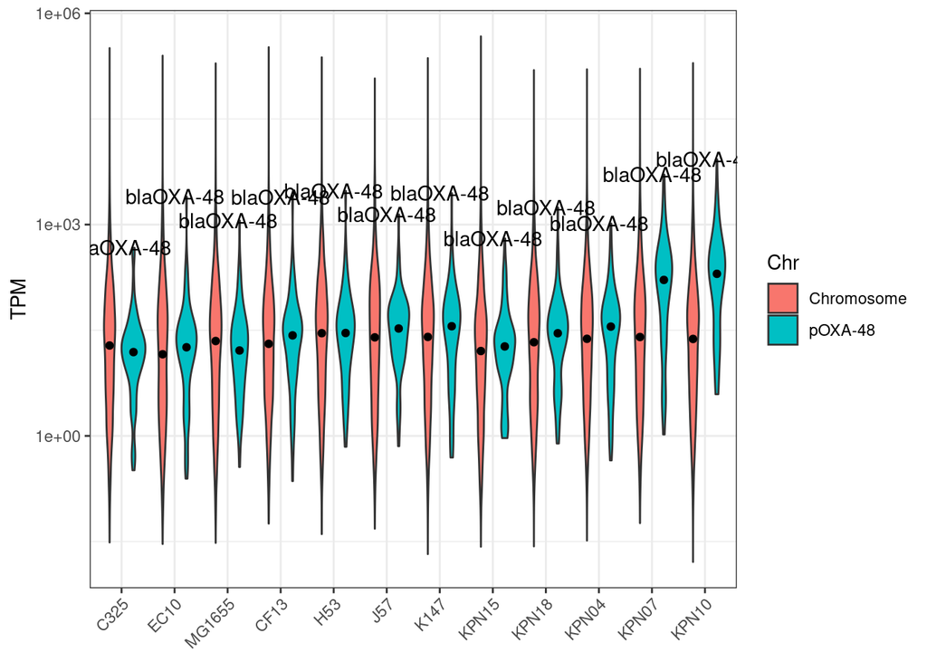

```r
sporder <- c("C325", "EC10","MG1655","CF13","H53","J57","K147","KPN15","KPN18","KPN04","KPN07","KPN10")
alldf$Strain <- factor(alldf$Strain, levels=sporder)

tcplot <- ggplot(alldf, aes(Strain, median_tpm)) + theme_bw() + geom_violin(aes(Strain, median_tpm, fill=Chr), position=position_dodge(.9)) +
  xlab(NULL) + ylab("TPM") + scale_y_continuous(trans = "log10") +
  stat_summary(aes(group=Chr), position=position_dodge(.9), fun = "median", geom = "point", color = "black") +
  geom_text(aes(Strain, median_tpm, label=GeneID), data=alldf[alldf$GeneID %in% "blaOXA-48", ]) +
  theme(axis.text.x = element_text(angle = 45, hjust = 1))
tcplot
```

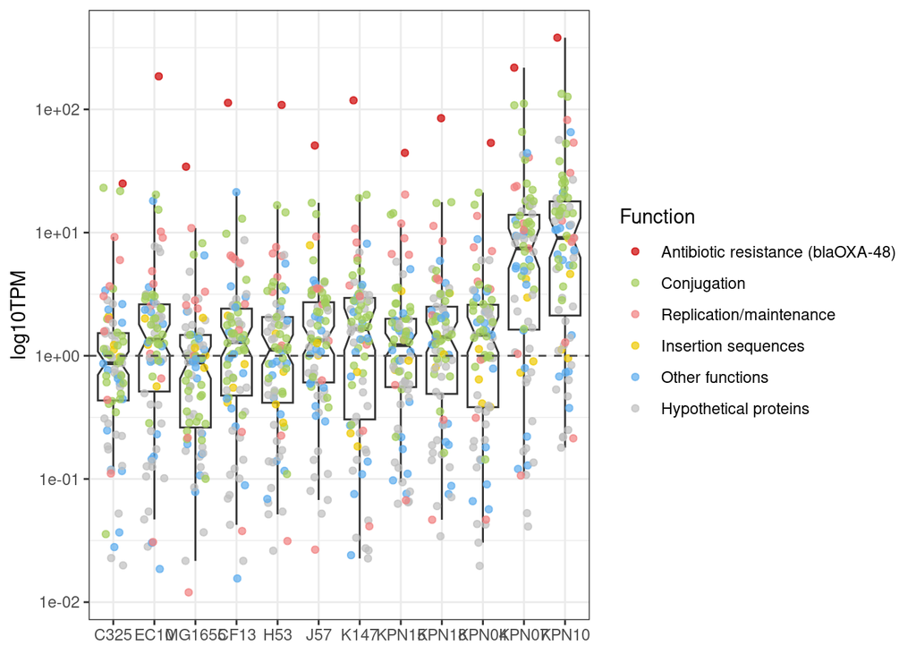

```r
sporder <- c("C325", "EC10","MG1655","CF13","H53","J57","K147","KPN15","KPN18","KPN04","KPN07","KPN10")
plasdf$Strain <- factor(plasdf$Strain, levels=sporder)

plasplot <- ggplot(plasdf, aes(Strain, median_tpm_norm)) +
  theme(axis.text.x=element_text(size=11), panel.background = element_rect(fill = "gray96")) +
  geom_boxplot(notch=TRUE, outlier.shape=NA) + geom_jitter(alpha=0.7, position=position_jitter(seed=5, width=0.25), aes(color=Function)) +
  scale_color_manual(breaks=c("Antibiotic resistance (blaOXA-48)", "Conjugation", "Replication/maintenance", "Insertion sequences", "Other functions", "Hypothetical proteins"),
                     values=c("red3", "darkolivegreen3", "lightcoral", "gold2", "steelblue2", "gray")) +
  xlab(NULL) + ylab("log10TPM") + scale_y_continuous(trans = "log10") +
  geom_hline(yintercept=1, linetype="dashed", color="gray30") + theme_bw()
plasplot
```

#### Heatmap of pOXA-48 normalized TPM values

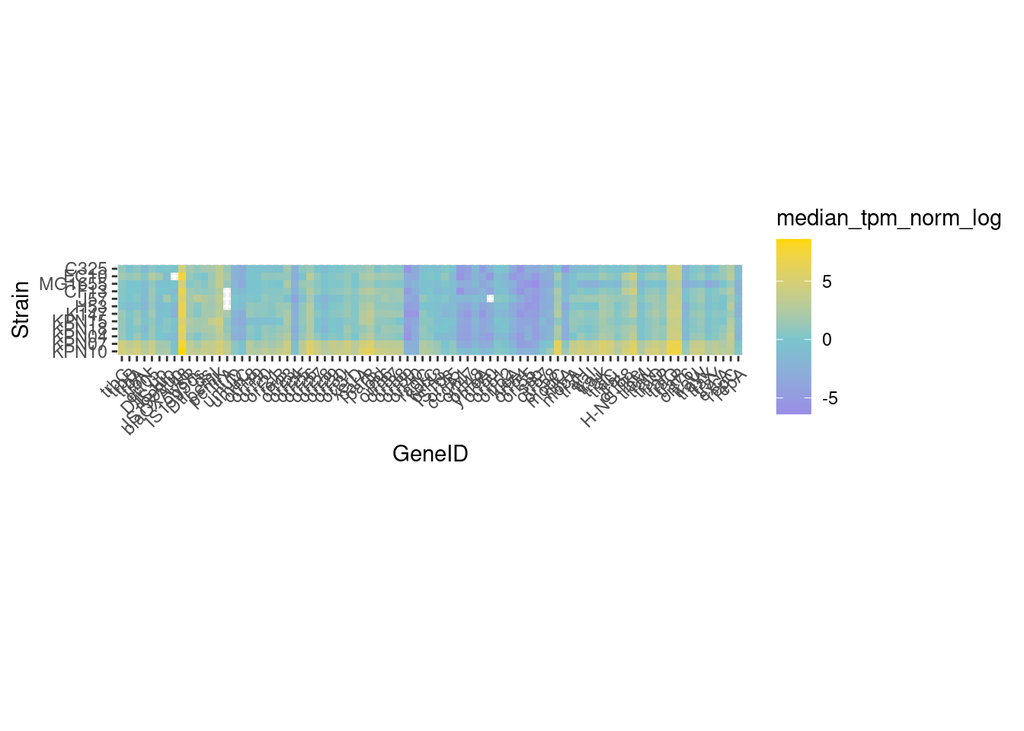

```r
sporder <- c("KPN10","KPN07","KPN04","KPN18","KPN15","K147","H53","J57","CF13","MG1655","EC10","C325")
plasdf$Strain <- factor(plasdf$Strain, levels=sporder)
plasdf$GeneID <- factor(plasdf$GeneID, level = unique(plasdf$GeneID))
plasdf$median_tpm_norm_log <- log2(plasdf$median_tpm_norm)

plasheatmap <- ggplot(plasdf, aes(GeneID, Strain, fill=median_tpm_norm_log)) + geom_tile() + coord_fixed() +
  theme(axis.text.x = element_text(angle = 45, hjust = 1)) +
  scale_fill_gradient2(low = "mediumpurple2",
                      mid = "cadetblue3",
                      high = "gold1")
plasheatmap
```